# Applied Probability

# Overview of Elementary Probability

## Sample space, outcomes and events

Definition 2.1 A collection of all elementary results, or **outcomes** of an experiment, is called a **sample space**.

Definition 2.2 Any set of outcomes is an **event**. Thus, events are subsets of the sample space.

Common Notation: $\Omega$ or $S$ for the sample space $\emptyset$ for the empty set/event. Note: $\emptyset \subset \Omega$ for any $\Omega$ $A,B,E$ and other capital letters for events Note: $E \subset \Omega$ $\omega$ or $s$ for individual outcomes Note: $\omega \in \Omega$ is an outcome; $\{\omega\} \subset \Omega$ is an event $\mathbb{P}[E] = \mathbf{P}[E]$ for the probability of an event

Example 2.4 A tossed die can produce one of 6 possible outcomes: 1 dot, through 6 dots. Each outcome is an event. There are other events: observing an even number of dots, an odd number of dots, a number of dots less than 3, etc. $\Omega = \{1,2,3,4,5,6\}$ $A=1, B=2, \dots, F=6$ $O=\{1,3,5\}, E=\{2,4,6\}$ $L=\{1,2\}$

Complement

```r
library(VennDiagram)
range <- paste("10",1:10,sep="")
x <- list(
  A = sample(range,5),
  B = sample(range,5)
)


venn.diagram(x, filename = "venn-2-dimensions.png")
```

```
## [1] 1
```

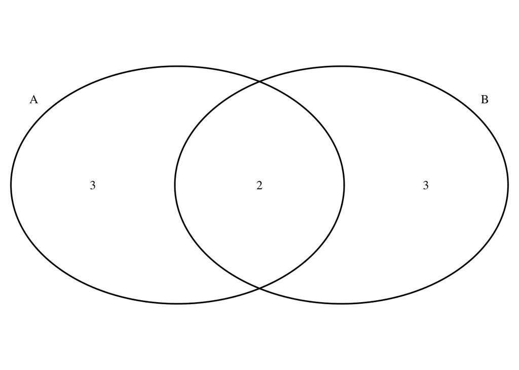

```r
# Helper function to display Venn diagram
display_venn <- function(x, ...){
  library(VennDiagram)
  grid.newpage()
  venn_object <- venn.diagram(x, filename = NULL, category.names = c("A","B"))
  grid.draw(venn_object)
}

# Three dimension Venn plot
display_venn(x[1:2])
```

$\Rightarrow$ $A \setminus B = A \cap \bar{B}$ defines the set difference $\Rightarrow$ De Morgan’s laws establish the relation between union, intersection and complementation:
$$\overline{E_1 \cup \dots \cup E_n} = \bar{E_n} \cap \dots \cap
\bar{E_n}; \quad \overline{E_1 \cap \dots \cap E_n} = \bar{E_n} \cup
\dots \cup \bar{E_n}$$
Defnition 2.7 Events A and B are **disjoint** if their intersection is empty,
$$A \cap B =
\emptyset.$$
Events $A_1,A_2,A_3,\dots$ are **mutually exclusive** or **pairwise disjoint** if any two of these events are disjoint, i.e.,
$$A_i \cap
A_j = \emptyset \text{ for any } i \neq j.$$

Definition 2.8 Events $A,B,C,\dots$ are **exhaustive** if their union equals the whole sample space, i.e.,
$$A \cup B \cup C \cup \dots =
\Omega.$$

A collection of mutually exclusive, exhaustive events is called a partition of the sample space.